# 2019 厚數據與意義探勘工作坊 民調資料探索 我的筆記與作業

陳聖勳

2019.8.16

## 關於資料來源

這個練習的資料，是個來自兩波網路調查。這是個依受訪者id合併之後的「定群追蹤資料」（panel data）。由smilepoll.tw提供。第一筆（代號B）是「統獨意見大調查」，調查時間： 2018. 10.22～2018. 11.13，N=886（完成率86.7%）；第二筆（代號D）是「2018地方選舉選後心情札記」，調查時間：2019.01.21～2019.02.19，N=1,297 (完成率78%)。

## 專案準備

請開啟一個新的專案，將語法檔及資料檔（dataBD.rda）都放入該專案資料夾內。

## 讀入資料與變數觀察

[output not shown]

```
##
## 性別 (x) <categorical>
## # total N=579  valid N=576  mean=0.43  sd=0.50
##
##  val label frq raw.prc valid.prc cum.prc
##    0    女 329   56.82     57.12   57.12
##    1    男 247   42.66     42.88  100.00
##   NA    NA   3    0.52        NA      NA
```

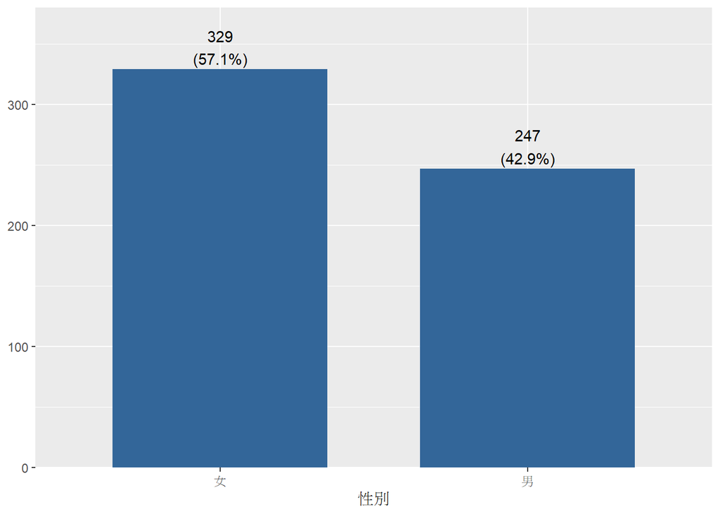

```
##
## x <numeric>
## # total N=579  valid N=579  mean=34.95  sd=11.40
##
##   val frq raw.prc valid.prc cum.prc
##    15   2    0.35      0.35    0.35
##    17   4    0.69      0.69    1.04
##    18   4    0.69      0.69    1.73
##    19  12    2.07      2.07    3.80
##    20  11    1.90      1.90    5.70
##    21  13    2.25      2.25    7.94
##    22  13    2.25      2.25   10.19
##    23  21    3.63      3.63   13.82
##    24  20    3.45      3.45   17.27
##    25  23    3.97      3.97   21.24
```

[output cut: 45 more lines]

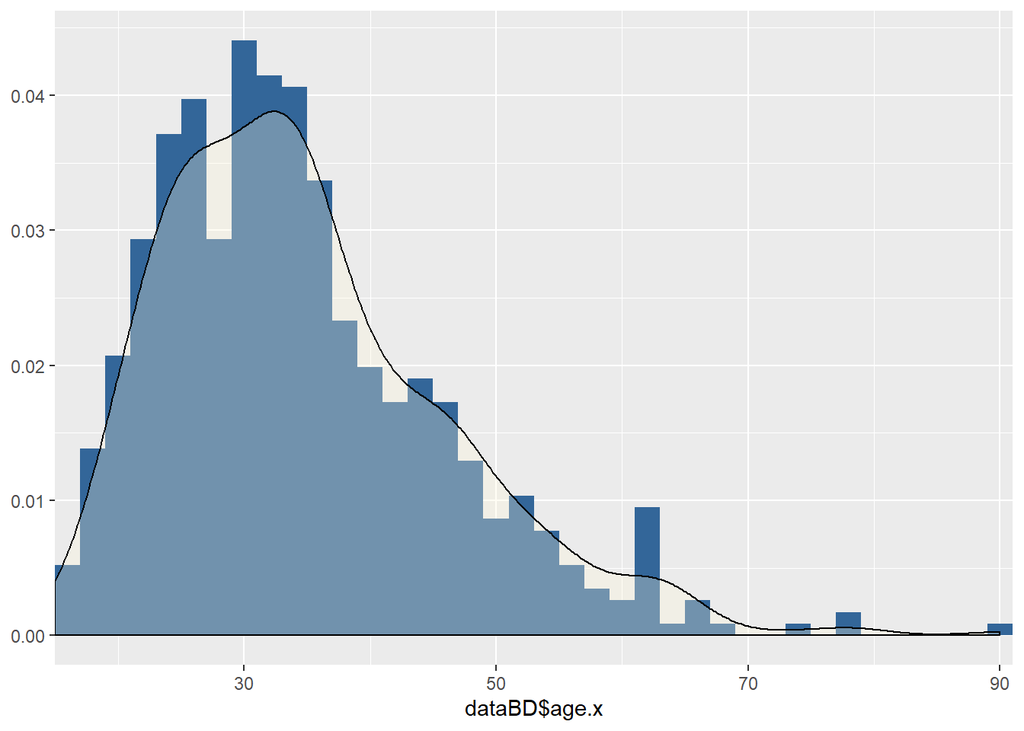

```
##
## 教育程度 (x) <categorical>
## # total N=579  valid N=572  mean=2.03  sd=0.53
##
##  val    label frq raw.prc valid.prc cum.prc
##    1 大專以下  72   12.44     12.59   12.59
##    2     大專 408   70.47     71.33   83.92
##    3   研究所  92   15.89     16.08  100.00
##   NA       NA   7    1.21        NA      NA
```

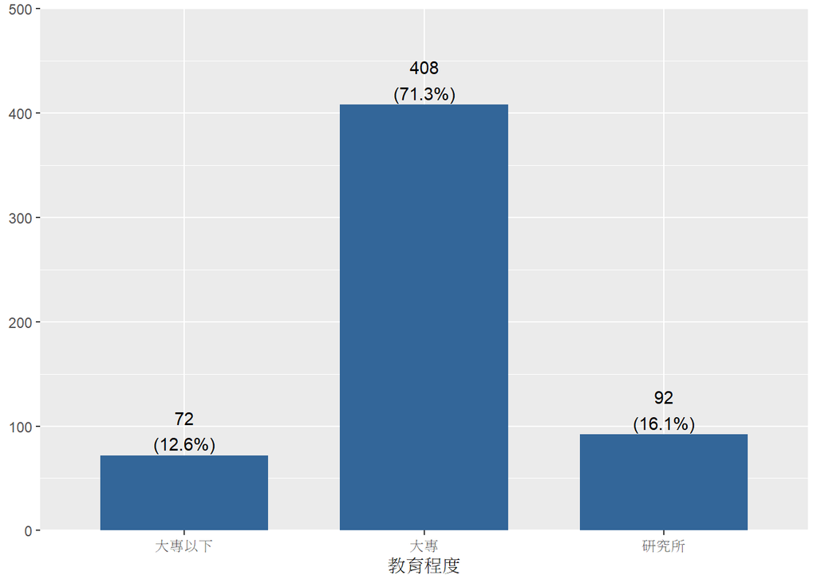

```
##
## 居住地 (x) <categorical>
## # total N=579  valid N=558  mean=7.98  sd=5.58
##
##  val                      label frq raw.prc valid.prc cum.prc
##    1                     台北市  56    9.67     10.04   10.04
##    2                     新北市 120   20.73     21.51   68.64
##    3                     基隆市   5    0.86      0.90   70.07
##    4                     桃園市  42    7.25      7.53   77.60
##    5                     新竹市  13    2.25      2.33   79.93
##    6                     新竹縣  12    2.07      2.15   82.08
##    7                     苗栗縣   8    1.38      1.43   83.51
##    8                     台中市  73   12.61     13.08   96.59
##    9                     彰化縣  19    3.28      3.41  100.00
##   10                     南投縣   5    0.86      0.90   10.93
##   11                     雲林縣  18    3.11      3.23   14.16
##   12                     嘉義市   5    0.86      0.90   15.05
##   13                     嘉義縣  13    2.25      2.33   17.38
##   14                     台南市  45    7.77      8.06   25.45
##   15                     高雄市  99   17.10     17.74   43.19
##   16                     屏東縣  14    2.42      2.51   45.70
##   17                     台東縣   0    0.00      0.00   45.70
##   18                     花蓮縣   5    0.86      0.90   46.59
##   19                     宜蘭縣   3    0.52      0.54   47.13
##   20                     澎湖縣   2    0.35      0.36   69.00
##   21                     金門縣   1    0.17      0.18   69.18
##   22                     連江縣   0    0.00      0.00   69.18
##   23 中國大陸(含香港、澳門)地區   0    0.00      0.00   69.18
##   24                       其他   0    0.00      0.00   69.18
##   NA                         NA  21    3.63        NA      NA
```

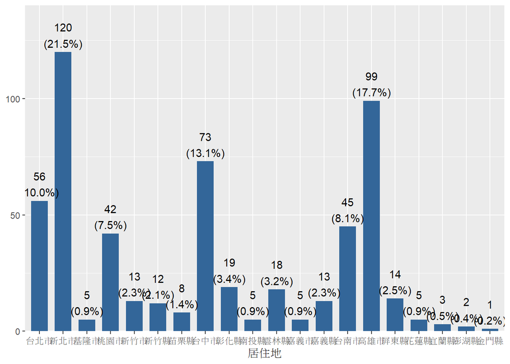

#### 請依你圖表上的資訊，在此寫下你對這筆資料的基本印象及看法：